# Analysis of Big-Mart Dataset

dataMunglers

24 October 2017

### Team Members

- **[Ahmet Yetkin Eser](https://www.linkedin.com/in/ahmet-yetkin-eser-04178a40/)**
- **[Berkay Soyer](https://www.linkedin.com/in/berkaysoyer/)**
- **Feray Ece Topcu**

### Our Objective

- The data scientists at BigMart have collected 2013 sales data for 1559 products across 10 stores in different cities. The main objective is to understand whether specific properties of products and/or stores play a significant role in terms of increasing or decreasing sales volume. To achieve this goal, we will build a predictive model and find out the sales of each product at a particular store. This will help BigMart to boost their sales by learning optimised product organization inside stores.

### Dataset

- We take data from analyticsvidhya.com, Our data is [Big Mart Sales Practise Problem](https://datahack.analyticsvidhya.com/contest/practice-problem-big-mart-sales-iii/) Data, It is open competition now and its final date is 31 Dec 2017. We downloaded training and test dataset as a csv file.

#### About BigMart

- Big Mart is One Stop Shopping center and Free Marketplace. Buy, sell and advertise without fee or at low cost. Find more information about BigMart [Here](http://www.bigmart.com/about-us.html).

## 1.Exploring The BigMart Dataset

- Call Libraries and Read Data from File.

```r
library(dplyr)
library(tidyr)
library(stringr)
library(ggplot2)
library(corrplot)
library(dummies)
setwd("C:/Users/ecetp/Downloads/MEF/BDA 503 - R/Project-BigMart Sales")
train <- read.csv('bigMartTrain.csv')
test  <- read.csv('bigMartTest.csv')
```

- View the structure of train with *glimpse* function.

```r
glimpse(train)
```

```
## Observations: 8,523
## Variables: 12
## $ Item_Identifier           <fctr> FDA15, DRC01, FDN15, FDX07, NCD19, ...
## $ Item_Weight               <dbl> 9.300, 5.920, 17.500, 19.200, 8.930,...
## $ Item_Fat_Content          <fctr> Low Fat, Regular, Low Fat, Regular,...
## $ Item_Visibility           <dbl> 0.016047301, 0.019278216, 0.01676007...
## $ Item_Type                 <fctr> Dairy, Soft Drinks, Meat, Fruits an...
## $ Item_MRP                  <dbl> 249.8092, 48.2692, 141.6180, 182.095...
## $ Outlet_Identifier         <fctr> OUT049, OUT018, OUT049, OUT010, OUT...
## $ Outlet_Establishment_Year <int> 1999, 2009, 1999, 1998, 1987, 2009, ...
## $ Outlet_Size               <fctr> Medium, Medium, Medium, , High, Med...
## $ Outlet_Location_Type      <fctr> Tier 1, Tier 3, Tier 1, Tier 3, Tie...
## $ Outlet_Type               <fctr> Supermarket Type1, Supermarket Type...
## $ Item_Outlet_Sales         <dbl> 3735.1380, 443.4228, 2097.2700, 732....
```

- As a conclusion of glimpse, we can see that our train dataset has 12 columns and 8523 rows. We should observe all columns one by one to explore data.

#### 1.1. Factor Columns

- **Item_Identifier** : Unique Product ID.

```r
train %>%
  summarise(n_distinct(Item_Identifier))
```

```
##   n_distinct(Item_Identifier)
## 1                        1559
```

Item_Identifier column has 1559 unique value. So, we can say we will examine 1559 unique item properties due to the stores.

- **Item_Fat_Content** : Whether the product is low fat or not.

```r
train %>%
  group_by(Item_Fat_Content) %>%
  summarise(Count = n(),Perc=round(n()/nrow(.)*100,2)) %>%
  arrange(desc(Count))
```

```
## # A tibble: 5 x 3
##   Item_Fat_Content Count  Perc
##             <fctr> <int> <dbl>
## 1          Low Fat  5089 59.71
## 2          Regular  2889 33.90
## 3               LF   316  3.71
## 4              reg   117  1.37
## 5          low fat   112  1.31
```

Item_Fat_Content distribution can be seen as belove summary. Low fat items have highest rate, so we can say low fat items reside on stores generally. There is corruption about string values, such as “Low fat”/“low fat”/“LF” or “Regular” / “reg” , we know these string values represent same value and so, we should clean this column values on cleaning part.

- **Item_Type** : The category to which the product belongs.

```r
train%>%
  group_by(Item_Type) %>%
  summarise(Count = n(), Perc = round(n() / nrow(.) * 100, 2)) %>%
  arrange(desc(Count))
```

```
## # A tibble: 16 x 3
##                Item_Type Count  Perc
##                   <fctr> <int> <dbl>
##  1 Fruits and Vegetables  1232 14.46
##  2           Snack Foods  1200 14.08
##  3             Household   910 10.68
##  4          Frozen Foods   856 10.04
##  5                 Dairy   682  8.00
##  6                Canned   649  7.61
##  7          Baking Goods   648  7.60
##  8    Health and Hygiene   520  6.10
##  9           Soft Drinks   445  5.22
## 10                  Meat   425  4.99
## 11                Breads   251  2.94
## 12           Hard Drinks   214  2.51
## 13                Others   169  1.98
## 14         Starchy Foods   148  1.74
## 15             Breakfast   110  1.29
## 16               Seafood    64  0.75
```

Train dataset has 16 different item_type value and “Fruits and Vegetables” items reside on stores popularly.

- **Outlet_Identifier** : Unique Store ID

```r
train %>%
  group_by(Outlet_Identifier) %>%
  summarise(Count = n(), Perc = round(n() / nrow(.) * 100, 2)) %>%
  arrange(desc(Count))
```

```
## # A tibble: 10 x 3
##    Outlet_Identifier Count  Perc
##               <fctr> <int> <dbl>
##  1            OUT027   935 10.97
##  2            OUT013   932 10.94
##  3            OUT035   930 10.91
##  4            OUT046   930 10.91
##  5            OUT049   930 10.91
##  6            OUT045   929 10.90
##  7            OUT018   928 10.89
##  8            OUT017   926 10.86
##  9            OUT010   555  6.51
## 10            OUT019   528  6.20
```

Outlet_Identifier data show that train dataset includes item information of 10 different stores.

- **Outlet_Size** : The size of the store in terms of ground area covered.

```r
train%>%
  group_by(Outlet_Size) %>%
  summarise(Count = n(),Perc = round(n() / nrow(.) * 100, 2)) %>%
  arrange(desc(Count))
```

```
## # A tibble: 4 x 3
##   Outlet_Size Count  Perc
##        <fctr> <int> <dbl>
## 1      Medium  2793 32.77
## 2              2410 28.28
## 3       Small  2388 28.02
## 4        High   932 10.94
```

As we can see, outlet_size have some null values. So, on cleaning part we should consider about this column,also.

- **Outlet_Location_Type** : The type of city in which the store is located

```r
train%>%
  group_by(Outlet_Location_Type) %>%
  summarise(Count = n(),Perc = round(n()/nrow(.) * 100, 2)) %>%
  arrange(desc(Count))
```

```
## # A tibble: 3 x 3
##   Outlet_Location_Type Count  Perc
##                 <fctr> <int> <dbl>
## 1               Tier 3  3350 39.31
## 2               Tier 2  2785 32.68
## 3               Tier 1  2388 28.02
```

Data of Outlet_Location_Type column distribution is fair for each type.

- **Outlet_Type** : Whether the outlet is just a grocery store or some sort of supermarket

```r
train%>%
  group_by(Outlet_Type)%>%
  summarise(Count=n(),Perc=round(n()/nrow(.)*100,2))%>%
  arrange(desc(Count))
```

```
## # A tibble: 4 x 3
##         Outlet_Type Count  Perc
##              <fctr> <int> <dbl>
## 1 Supermarket Type1  5577 65.43
## 2     Grocery Store  1083 12.71
## 3 Supermarket Type3   935 10.97
## 4 Supermarket Type2   928 10.89
```

This result show that we have item information on “Supermarket Type1” store with the highest rate (65.43). It means, our data includes “Supermarket Type1” store mostly.

#### 1.2. Numerical Columns

- **Item_Weight** : Weight of product.

```r
train%>%
    summarise(is_NULL=sum(is.na(Item_Weight)==1),
              is_NOT_NULL=sum(!is.na(Item_Weight)==1)
              )
```

```
##   is_NULL is_NOT_NULL
## 1    1463        7060
```

```r
train%>%
  filter(!is.na(Item_Weight))%>%
  summarise(
    Max=max(Item_Weight),
    Min=min(Item_Weight),
    Mean=mean(Item_Weight),
    Median=median(Item_Weight),
    QUA1=quantile(Item_Weight,1/4),
    QUA3=quantile(Item_Weight,3/4),
    IQR=IQR(Item_Weight)
  )
```

```
##     Max   Min     Mean Median    QUA1  QUA3     IQR
## 1 21.35 4.555 12.85765   12.6 8.77375 16.85 8.07625
```

The result show that Item_Weight column has 1463 null value, so cleaning part we should consider this column also. When we exclude the null values, the heaviest item is 21.35 gr and the lightest ite is 4.555 gr.

- **Item_Visibility** : The % of total display area of all products in a store allocated to the particular product.

```r
train%>%
    summarise(is_NULL=sum(is.na(Item_Visibility)==1),
              is_NOT_NULL=sum(!is.na(Item_Visibility)==1)
              )
```

```
##   is_NULL is_NOT_NULL
## 1       0        8523
```

```r
train%>%
  filter(!is.na(Item_Visibility))%>%
  summarise(
    Max=max(Item_Visibility),
    Min=min(Item_Visibility),
    Mean=mean(Item_Visibility),
    Median=median(Item_Visibility),
    QUA1=quantile(Item_Visibility,1/4),
    QUA3=quantile(Item_Visibility,3/4),
    IQR=IQR(Item_Visibility)
  )
```

```
##         Max Min       Mean     Median       QUA1       QUA3        IQR
## 1 0.3283909   0 0.06613203 0.05393093 0.02698948 0.09458529 0.06759582
```

There is no null value on Item_Visibility column but from minumum value we can say there is “0” value on column.

- **Item_MRP** : Maximum Retail Price (list price) of the product.

```r
train%>%
    summarise(is_NULL=sum(is.na(Item_MRP)==1),
              is_NOT_NULL=sum(!is.na(Item_MRP)==1)
              )
```

```
##   is_NULL is_NOT_NULL
## 1       0        8523
```

```r
train%>%
  filter(!is.na(Item_MRP))%>%
  summarise(
    Max=max(Item_MRP),
    Min=min(Item_MRP),
    Mean=mean(Item_MRP),
    Median=median(Item_MRP),
    QUA1=quantile(Item_MRP,1/4),
    QUA3=quantile(Item_MRP,3/4),
    IQR=IQR(Item_MRP)
  )
```

```
##        Max   Min     Mean   Median    QUA1     QUA3     IQR
## 1 266.8884 31.29 140.9928 143.0128 93.8265 185.6437 91.8172
```

Good news, there is no null or “0” value on ITEM_MRP column. MAx price is 266.8884 and min price is 31.29.

- **Outlet_Establishment_Year** : The year in which store was established.

```r
train%>%
    summarise(is_NULL=sum(is.na(Outlet_Establishment_Year)==1),
              is_NOT_NULL=sum(!is.na(Outlet_Establishment_Year)==1)
              )
```

```
##   is_NULL is_NOT_NULL
## 1       0        8523
```

```r
train%>%
  filter(!is.na(Outlet_Establishment_Year))%>%
  summarise(
    Max=max(Outlet_Establishment_Year),
    Min=min(Outlet_Establishment_Year),
    Mean=mean(Outlet_Establishment_Year),
    Median=median(Outlet_Establishment_Year),
    QUA1=quantile(Outlet_Establishment_Year,1/4),
    QUA3=quantile(Outlet_Establishment_Year,3/4),
    IQR=IQR(Outlet_Establishment_Year)
  )
```

```
##    Max  Min     Mean Median QUA1 QUA3 IQR
## 1 2009 1985 1997.832   1999 1987 2004  17
```

- **Item_Outlet_Sales** : Sales of the product in the particulat store. **This is the outcome variable to be predicted.**

```r
train%>%
    summarise(is_NULL=sum(is.na(Item_Outlet_Sales)==1),
              is_NOT_NULL=sum(!is.na(Item_Outlet_Sales)==1)
              )
```

```
##   is_NULL is_NOT_NULL
## 1       0        8523
```

```r
train%>%
  filter(!is.na(Item_Outlet_Sales))%>%
  summarise(
    Max=max(Item_Outlet_Sales),
    Min=min(Item_Outlet_Sales),
    Mean=mean(Item_Outlet_Sales),
    Median=median(Item_Outlet_Sales),
    QUA1=quantile(Item_Outlet_Sales,1/4),
    QUA3=quantile(Item_Outlet_Sales,3/4),
    IQR=IQR(Item_Outlet_Sales)
  )
```

```
##        Max   Min     Mean   Median     QUA1     QUA3      IQR
## 1 13086.96 33.29 2181.289 1794.331 834.2474 3101.296 2267.049
```

Item_Outlet_Sales column has no null values.

- If we want to see good summary of numeric columns, we should use **summary** function as below.

```r
summary(train)
```

```
##  Item_Identifier  Item_Weight     Item_Fat_Content Item_Visibility
##  FDG33  :  10    Min.   : 4.555   LF     : 316     Min.   :0.00000
##  FDW13  :  10    1st Qu.: 8.774   low fat: 112     1st Qu.:0.02699
##  DRE49  :   9    Median :12.600   Low Fat:5089     Median :0.05393
##  DRN47  :   9    Mean   :12.858   reg    : 117     Mean   :0.06613
##  FDD38  :   9    3rd Qu.:16.850   Regular:2889     3rd Qu.:0.09459
##  FDF52  :   9    Max.   :21.350                    Max.   :0.32839
##  (Other):8467    NA's   :1463
##                  Item_Type       Item_MRP      Outlet_Identifier
##  Fruits and Vegetables:1232   Min.   : 31.29   OUT027 : 935
##  Snack Foods          :1200   1st Qu.: 93.83   OUT013 : 932
##  Household            : 910   Median :143.01   OUT035 : 930
##  Frozen Foods         : 856   Mean   :140.99   OUT046 : 930
##  Dairy                : 682   3rd Qu.:185.64   OUT049 : 930
##  Canned               : 649   Max.   :266.89   OUT045 : 929
##  (Other)              :2994                    (Other):2937
##  Outlet_Establishment_Year Outlet_Size   Outlet_Location_Type
##  Min.   :1985                    :2410   Tier 1:2388
##  1st Qu.:1987              High  : 932   Tier 2:2785
##  Median :1999              Medium:2793   Tier 3:3350
##  Mean   :1998              Small :2388
##  3rd Qu.:2004
##  Max.   :2009
##
##             Outlet_Type   Item_Outlet_Sales
##  Grocery Store    :1083   Min.   :   33.29
##  Supermarket Type1:5577   1st Qu.:  834.25
##  Supermarket Type2: 928   Median : 1794.33
##  Supermarket Type3: 935   Mean   : 2181.29
##                           3rd Qu.: 3101.30
##                           Max.   :13086.97
##
```

### 2. Data Manipulation

- We discover some columns need to be corrected for a good analysis. So, we should manipulate some part of data. Let’s first combine the data sets. This will save our time as we don’t need to write separate codes for train and test data sets. To combine the two data frames, we must make sure that they have equal columns, which is not the case. Test data set has one less column (response variable). Let’s first add the column. We can give this column any value. An intuitive approach would be to extract the mean value of sales from train data set and use it as placeholder for test variable Item_Outlet_Sales. Anyways, let’s make it simple for now. I’ve taken a value -999. Now, we’ll combine the data sets.

```r
test$Item_Outlet_Sales <- -999
combi <- rbind(train, test)
```

- We saw on exploring part, Item_Weight column has null values which can affect the result of anaylsis. Impute missing value by median. We are using median because it is known to be highly robust to outliers. Moreover, for this problem, our evaluation metric is RMSE which is also highly affected by outliers. Hence, median is better in this case.

```r
combi$Item_Weight[is.na(combi$Item_Weight)] <- median(combi$Item_Weight, na.rm = TRUE)
table(is.na(combi$Item_Weight))
```

```
##
## FALSE
## 14204
```

- Let’s take up Item_Visibility. On exploration part above, we saw item visibility has zero value also, which is practically not feasible. Hence, we’ll consider it as a missing value and once again make the imputation using median.

```r
combi$Item_Visibility <- ifelse(combi$Item_Visibility == 0,
                           median(combi$Item_Visibility), combi$Item_Visibility)
```

- Let’s proceed to categorical variables now. During exploration, we saw there are mis-matched levels in variables which needs to be corrected. Item fat content should be corrected.

```r
combi$Item_Fat_Content <- str_replace(
           str_replace(
             str_replace(combi$Item_Fat_Content,"LF","Low Fat")
             ,"reg","Regular"),"low fat","Low Fat")

table(combi$Item_Fat_Content)
```

```
##
## Low Fat Regular
##    9185    5019
```

- We need to mutate new columns for more meaningful data. First, we evaluate Item_Identifier column because We discovered Item_Identifier column has special codes to recognize the type of item when we tried to understand data. So, letters on Item_Identifier column means Food, Drinks and etc. and numbers can be meaningful. We observed first three letters and two letters to control which of them is more meaningful. In any case, we hold both of them as two seperate column to use them later but now, we decided to use first two letters. (DR=Drink, FD=Food,NC=Non-Consumable) Secondly, we generate new Outlet_Age column from Outlet_Establishment_Year.

```r
##first two and three letter.
combi <-
  combi %>%
  mutate(Item_Identifier_Str3 = substr(Item_Identifier,1,3),  #First three letter of Item_Identifier.
         Item_Identifier_Str2 = substr(Item_Identifier,1,2),  #First second letter of Item_Identifier.
         Item_Identifier_Num=as.numeric(substr(Item_Identifier,4,6)), # Number part of Item_Identifier column.
         Outlet_Age=2013-Outlet_Establishment_Year, #Outlet Age
         PK=row_number())

#table(combi$Item_Identifier_Str3)

table(combi$Item_Identifier_Str2)
```

```
##
##    DR    FD    NC
##  1317 10201  2686
```

```r
#combi %>% summarise(n_distinct(Item_Identifier_Str3))
```

### 3. Data Visualizing

- We should use train data for visualizing because test data has no Item_Outlet_Sales column properly.

```r
#Split combined data into train and test data again to examine clearly.
new_train <- combi %>%
  filter(Item_Outlet_Sales != -999)

new_test <- combi %>%
  filter(Item_Outlet_Sales == -999)
#dim(new_train)
#dim(new_test)
```

#### 3.1. Visualizing Manipulated Data

- We manipulated Item_Fat_Content column; so graph it to see new version.

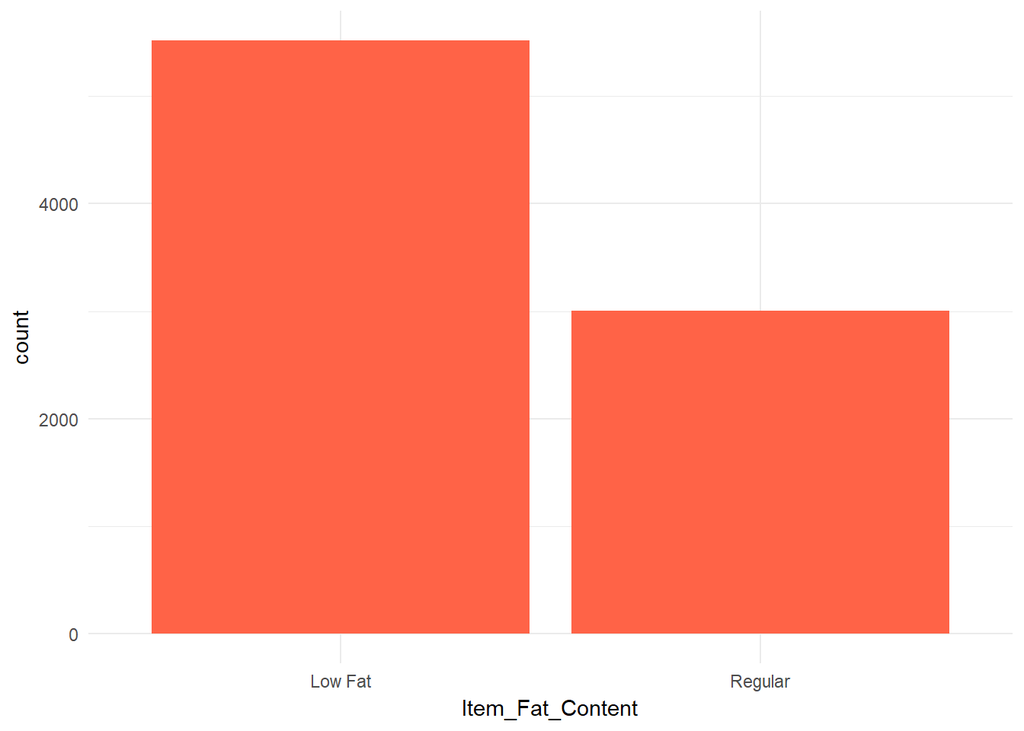

```r
# Looking at new Item_Fat_Content column.
qplot(x=Item_Fat_Content,data=new_train) +
  geom_bar(fill="tomato") +
  theme_minimal()
```

- Looking at Item type and Item Identifier because we observed there is a correlation between these two columns and we manipulated Item_Identifier_Content column as Item_Identifier_Str2 according to Item_Type data. (For example; if Item_Type = “Soft Drinks”, then Item_Identifier_Content starts with ‘DR’ .) As you can see on graph; manipulated Item_Identifier_Str2 column is correct and clear now. So output graph shows; DR (Drink) Idenfier has 3 types of item contents while FD(Food) Identifier has 11 types and NC (Non-Consumable) Identifier has 3 types of item contents. Additionally, we can see “Dairy” type is in both DR and FD. Furthermore; “Soft Drinks” consists the most number of items in “DR” Identifier, “Fruit and Vegetables” in “FD” Indetifier and “Household” in “NC” Identifier.

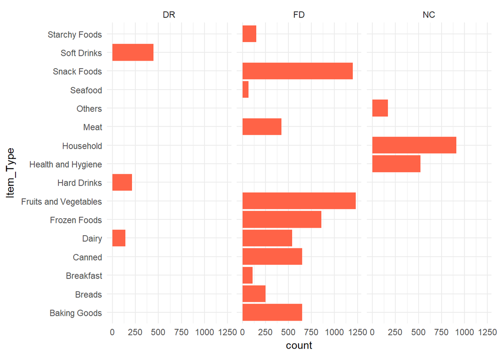

```r
# Looking at Item Type with facet wrap according to Item_Identifier_Str
qplot(x=Item_Type,data=new_train)+
  geom_bar(fill="tomato")+
  theme(axis.text = element_text(color="tomato"))+
  coord_flip() +
  theme_minimal() +
  facet_wrap(~Item_Identifier_Str2,nrow=1)
```

- Observing the relationship between Item Type/Item Identifier and Outlet_Identifier column to check Item distribution is similar for each Outlet. As we can see, the distribution of items on outlets is very similar.

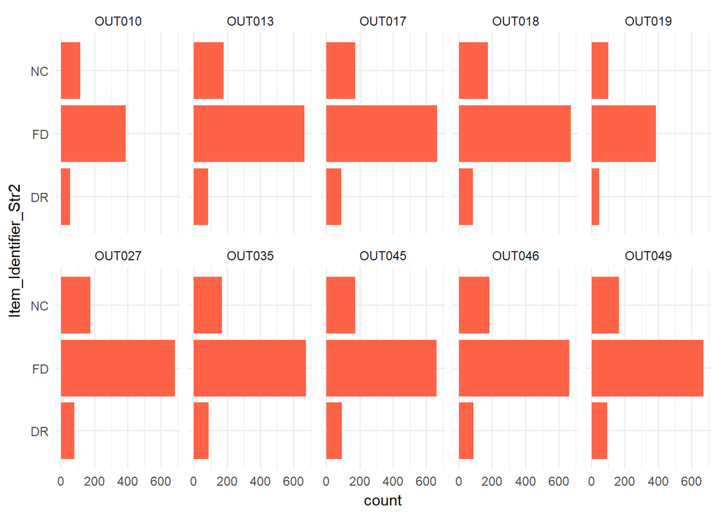

```r
# Looking at Item Type with facet wrap according to Outlet Identifier.

qplot(x = Item_Identifier_Str2, data = new_train) +
  geom_bar(fill = "tomato") +
  theme(axis.text = element_text(angle = 0)) +
  coord_flip() +
  theme_minimal() +
  facet_wrap(~Outlet_Identifier, nrow = 2)
```

#### 3.2. Visualizing Relationship between Item_Outlet_Sales and Other Columns

- Observing the histogram of Item Outlet Sales for looking of sales distribution. Also, the histogram of Item Outlet Sales with sqrt and log function are drawn, so we can decide which one is more close to normal distribution. As conclusion, we can say SQRT of Item Outlet Sales is much more normal than the others.

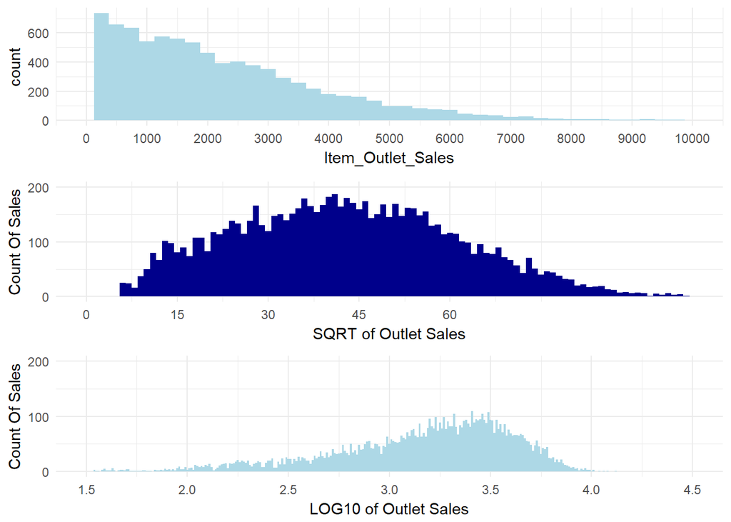

```r
library(gridExtra)

# Looking at Item_Outlet_Sales
p0 <- qplot(x = Item_Outlet_Sales, data = new_train, binwidth = 250,fill=I("lightblue")) +
  theme(axis.text.x = element_text(angle = 90, hjust = 1)) +
  theme_minimal() +
  scale_x_continuous(limits = c(0, 10000), breaks = seq(0, 10000, 1000))

# It is better now like normal distibution with sqrt and log10
p1 <- qplot(x = sqrt(Item_Outlet_Sales), data = new_train, binwidth = 1,
      ylab = "Count Of Sales",
      xlab = "SQRT of Outlet Sales",fill=I("darkblue")) +
  theme(axis.text.x = element_text(angle = 90),
        axis.text.y = element_text(angle = 30)) +
  theme_minimal() +
  scale_x_continuous(limits = c(0,100), breaks = seq(0,70,15)) +
  scale_y_continuous(limits = c(0,200), breaks = seq(0,200,100))

p2 <- qplot(x = log10(Item_Outlet_Sales+1), data = new_train, binwidth = 0.01,
      ylab = "Count Of Sales",
      xlab = "LOG10 of Outlet Sales",fill=I("lightblue")) +
  theme(axis.text.x = element_text(angle = 90),
        axis.text.y = element_text(angle = 30)) +
  theme_minimal() +
  scale_x_continuous(limits = c(1.5,4.5), breaks = seq(1.5, 4.5, 0.5)) +
  scale_y_continuous(limits = c(0,200), breaks = seq(0, 200, 100))

grid.arrange(p0, p1, p2, ncol=1)
```

- We can say SQRT of Item Outlet Sales has normal distribution according to above graphs.
- Boxplot grafiğine göre Low Fat ve Regular ürünlerdeki median değerleri benzer ama low fat ürünler çok daha yoğunlukla satıldığını distribution grafiğinde görebiliyoruz. (Berkay)

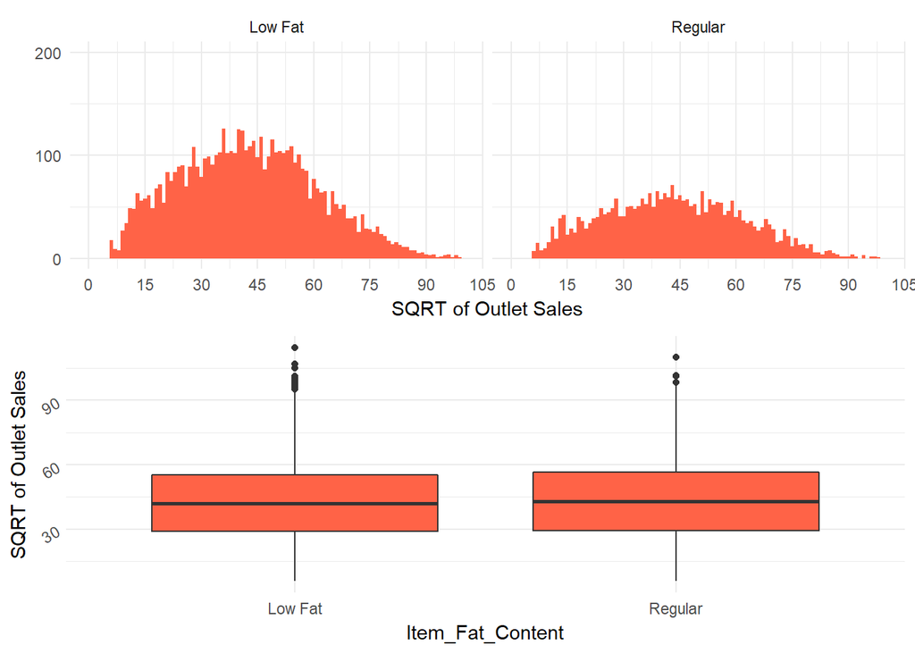

```r
# "Sales Distribution trough the Item Fat Content"
p0 <- qplot(x = sqrt(Item_Outlet_Sales), data = new_train, binwidth = 1,
      ylab = "",
      xlab = "SQRT of Outlet Sales",
      fill=I("tomato")) +
  theme(axis.text.x = element_text(angle = 90),
        axis.text.y = element_text(angle = 30)) +
  scale_x_continuous(limits = c(0,100), breaks = seq(0,120,15)) +
  scale_y_continuous(limits = c(0,200), breaks = seq(0,200,100)) +
  theme_minimal() +
  facet_wrap(~Item_Fat_Content)

#boxplot
p1 <- qplot(x = Item_Fat_Content, y = sqrt(Item_Outlet_Sales),
      ylab = "SQRT of Outlet Sales",
      data = new_train,
      geom = "boxplot",
      fill=I("tomato")) +
      theme_minimal() +
      theme(axis.text.x = element_text(angle = 0),
            axis.text.y = element_text(angle = 30))

grid.arrange(p0, p1, ncol=1)
```

- The relationship between Item_Type and Item_Outlet_Sales (Berkay)

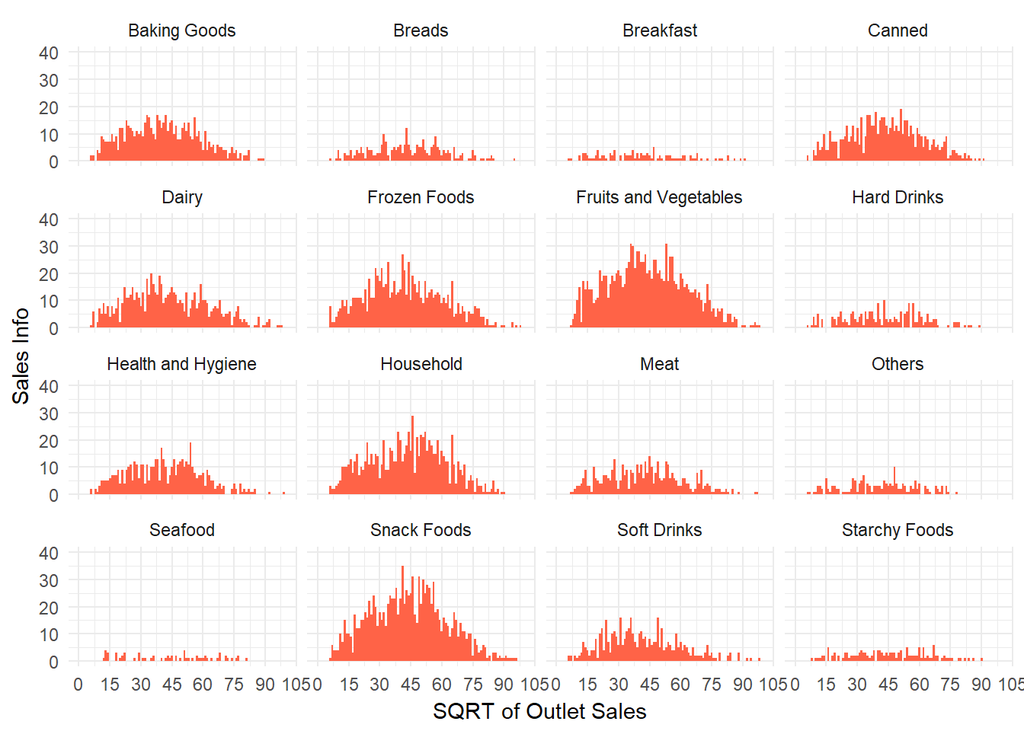

```r
# It is better now like normal distibution with sqrt and log10
p0 <- qplot(x = sqrt(Item_Outlet_Sales), data = new_train, binwidth = 1,
      ylab = "Sales Info",
      xlab = "SQRT of Outlet Sales",
      fill=I("tomato")) +
  theme(axis.text.x = element_text(angle = 90),
        axis.text.y = element_text(angle = 30)) +
  theme_minimal() +
  scale_x_continuous(limits = c(0,100), breaks = seq(0,120,15)) +
  scale_y_continuous(limits = c(0,40), breaks = seq(0,40,10)) +
  facet_wrap(~Item_Type)

p1 <- qplot(x = Item_Type, y = sqrt(Item_Outlet_Sales),
      ylab = "SQRT of Outlet Sales",
      data = new_train,
      geom = "boxplot",
      fill=I("tomato")) +
      theme_minimal() +
      theme(axis.text.x = element_text(angle = 90),
            axis.text.y = element_text(angle = 30))

p0
```

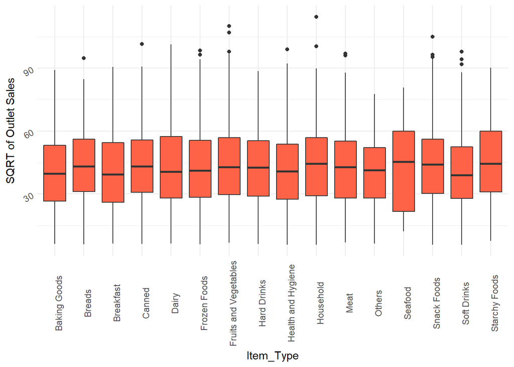

```r
p1
```

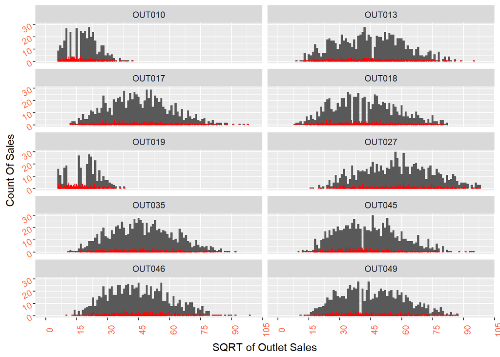

```r
# It is better now like normal distibution with sqrt and log10
qplot(x = sqrt(Item_Outlet_Sales), data = new_train, binwidth = 1,
      ylab = "Count Of Sales",
      xlab = "SQRT of Outlet Sales") +
  geom_bar(color = "red") +
  theme(axis.text.x = element_text(angle = 90,color = "tomato"),
        axis.text.y = element_text(angle = 30,color = "tomato")) +
  scale_x_continuous(limits = c(0,100), breaks = seq(0,120,15)) +
  scale_y_continuous(limits = c(0,30), breaks = seq(0,30,10)) +
  facet_wrap(~Outlet_Identifier,5)
```

- Observing the histogram of Item Outlet Sales according to Outlet Identifier to understand disttribution of sales in each shop.

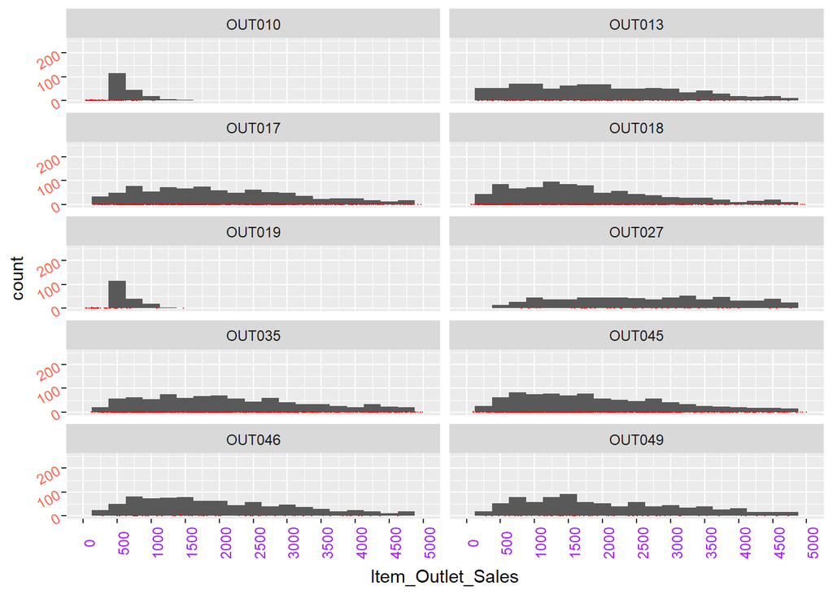

```r
qplot(x = Item_Outlet_Sales, data = new_train,binwidth = 250)+
  geom_bar(color = "red")+
  theme(axis.text.x = element_text(angle = 90,color = "purple"),
        axis.text.y = element_text(angle = 30,color = "tomato")) +
  scale_x_continuous(limits = c(0, 5000), breaks = seq(0, 5000, 500)) +
  scale_y_continuous(limits = c(0, 250), breaks = seq(0, 200, 100)) +
  facet_wrap(~Outlet_Identifier, nrow = 5)
```

- Observing the histogram of Item Outlet Sales according to Outlet Size to understand relationship between sales and outlet size.

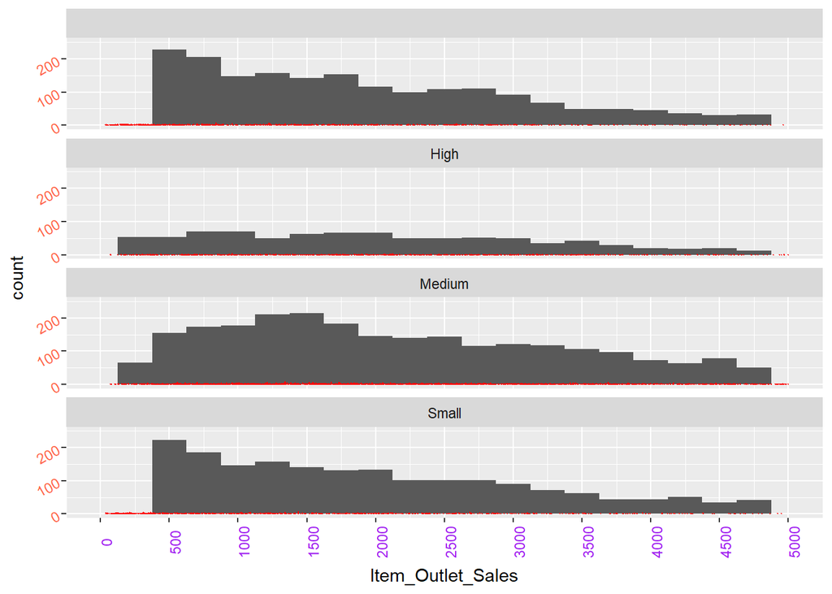

```r
# Looking at Item_Outlet_Sales according to Outlet_Size
qplot(x = Item_Outlet_Sales, data = new_train,binwidth = 250) +
  geom_bar(color = "red") +
  theme(axis.text.x = element_text(angle = 90, color = "purple"),
        axis.text.y = element_text(angle = 30, color = "tomato")) +
  scale_x_continuous(limits = c(0, 5000), breaks = seq(0, 5000, 500)) +
  scale_y_continuous(limits = c(0, 250), breaks = seq(0, 200, 100)) +
  facet_wrap(~Outlet_Size, nrow = 4)
```

```r
by(new_train$Item_Outlet_Sales, new_train$Outlet_Size, summary)
```

```
## new_train$Outlet_Size:
##    Min. 1st Qu.  Median    Mean 3rd Qu.    Max.
##   33.29  554.78 1443.45 1822.63 2681.51 9664.75
## --------------------------------------------------------
## new_train$Outlet_Size: High
##     Min.  1st Qu.   Median     Mean  3rd Qu.     Max.
##    73.24  1072.60  2050.66  2298.99  3166.38 10256.65
## --------------------------------------------------------
## new_train$Outlet_Size: Medium
##     Min.  1st Qu.   Median     Mean  3rd Qu.     Max.
##    69.24  1270.35  2251.07  2681.60  3691.20 13086.97
## --------------------------------------------------------
## new_train$Outlet_Size: Small
##    Min. 1st Qu.  Median    Mean 3rd Qu.    Max.
##   33.96  601.05 1544.66 1912.15 2824.32 9779.94
```

- We can observe different ways like line plot and box plot.

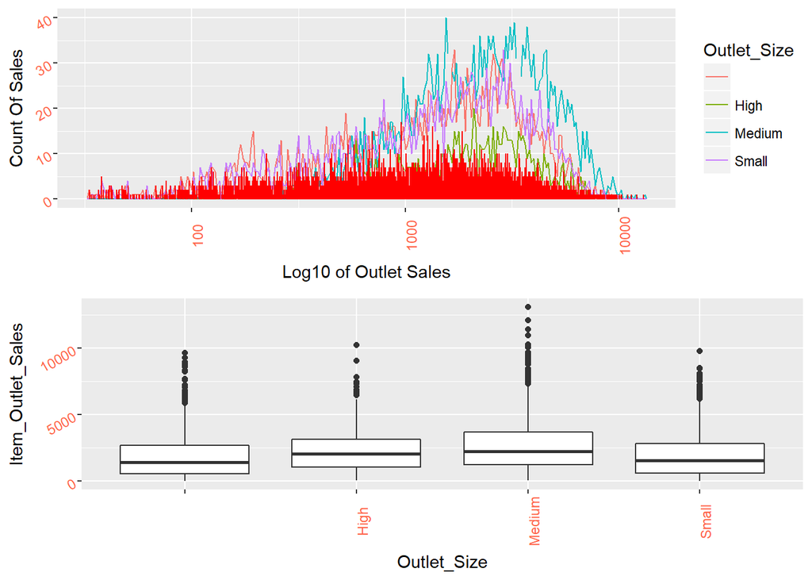

```r
p1 <- qplot(x = Item_Outlet_Sales, data = new_train, binwidth = 0.01,
      ylab = "Count Of Sales",
      xlab = "Log10 of Outlet Sales",
      geom = "freqpoly",
      color = Outlet_Size) +
  geom_bar(color = "red") +
  theme(axis.text.x = element_text(angle = 90, color = "tomato"),
        axis.text.y = element_text(angle = 30, color = "tomato")) +
  scale_x_continuous(limits = c(1.5,4.5), breaks = seq(1.5,4.5,0.5)) +
  scale_y_continuous(limits = c(0,40), breaks = seq(0,40,10)) +
  scale_x_log10()

p2 <- qplot(x = Outlet_Size, y = Item_Outlet_Sales,
      data = new_train,
      geom = "boxplot") +
  theme(axis.text.x = element_text(angle = 90, color = "tomato"),
        axis.text.y = element_text(angle = 30, color = "tomato"))


grid.arrange(p1, p2, ncol=1)
```

- We can observe different ways like line plot and box plot.

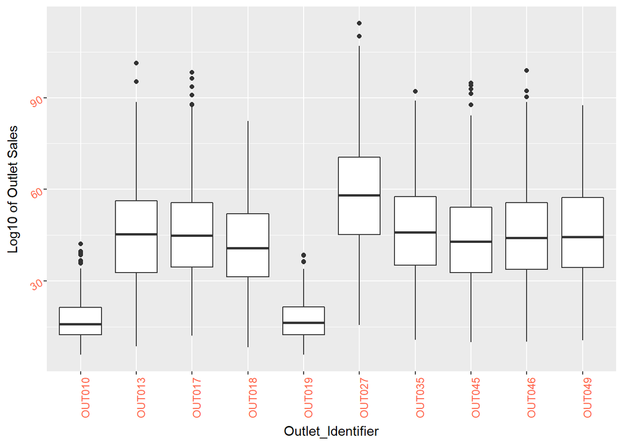

```r
qplot(x = Outlet_Identifier, y = sqrt(Item_Outlet_Sales),
      ylab = "Log10 of Outlet Sales",
      data = new_train,
      geom = "boxplot") +
  theme(axis.text.x = element_text(angle = 90, color = "tomato"),
        axis.text.y = element_text(angle = 30, color = "tomato"))
```

- We can observe different ways like line plot and box plot.

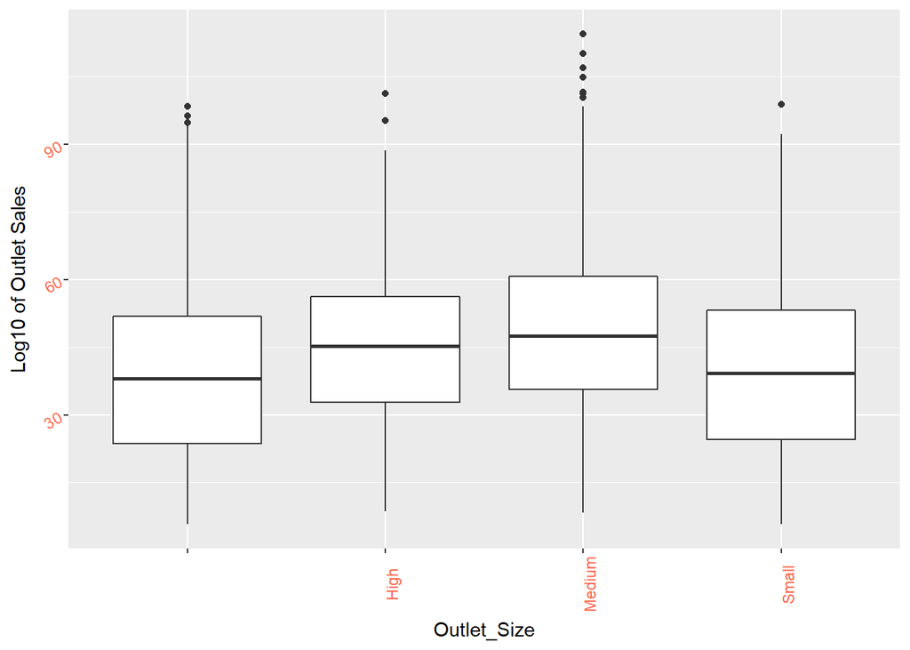

```r
qplot(x = Outlet_Size, y = sqrt(Item_Outlet_Sales),
      ylab = "Log10 of Outlet Sales",
      data = new_train,
      geom = "boxplot") +
  theme(axis.text.x = element_text(angle = 90, color = "tomato"),
        axis.text.y = element_text(angle = 30, color = "tomato"))
```

- We can observe different ways like line plot and box plot.

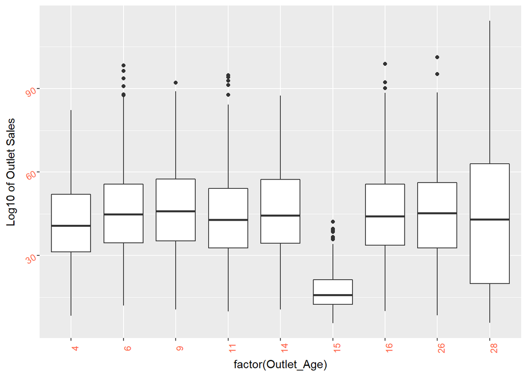

```r
qplot(x = factor(Outlet_Age), y = sqrt(Item_Outlet_Sales),
      ylab = "Log10 of Outlet Sales",
      data = new_train,
      geom = "boxplot") +
  theme(axis.text.x = element_text(angle = 90, color = "tomato"),
        axis.text.y = element_text(angle = 30, color = "tomato"))
```

* We can observe different ways like line plot and box plot.

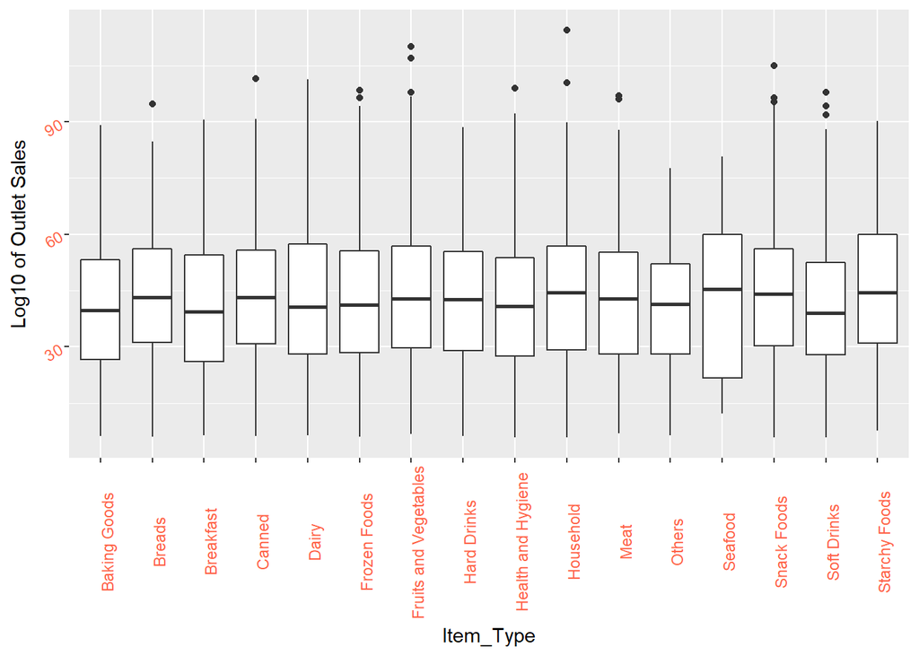

```r
qplot(x = Item_Type, y = sqrt(Item_Outlet_Sales),
      ylab = "Log10 of Outlet Sales",
      data = new_train,
      geom = "boxplot") +
  theme(axis.text.x = element_text(angle = 90, color = "tomato"),
        axis.text.y = element_text(angle = 30, color = "tomato"))
```

### 3. Prepering Data and Modeling based on kernels

- Note : In this chapter, we used [analyticsvidhya.com kernels](https://www.analyticsvidhya.com/blog/2016/02/complete-tutorial-learn-data-science-scratch/#five)
- Before we start to create new columns, look at our data types.

```r
new_combi <- rbind(new_train, new_test)

glimpse(new_combi)
```

```
## Observations: 14,204
## Variables: 17
## $ Item_Identifier           <fctr> FDA15, DRC01, FDN15, FDX07, NCD19, ...
## $ Item_Weight               <dbl> 9.300, 5.920, 17.500, 19.200, 8.930,...
## $ Item_Fat_Content          <chr> "Low Fat", "Regular", "Low Fat", "Re...
## $ Item_Visibility           <dbl> 0.016047301, 0.019278216, 0.01676007...
## $ Item_Type                 <fctr> Dairy, Soft Drinks, Meat, Fruits an...
## $ Item_MRP                  <dbl> 249.8092, 48.2692, 141.6180, 182.095...
## $ Outlet_Identifier         <fctr> OUT049, OUT018, OUT049, OUT010, OUT...
## $ Outlet_Establishment_Year <int> 1999, 2009, 1999, 1998, 1987, 2009, ...
## $ Outlet_Size               <fctr> Medium, Medium, Medium, , High, Med...
## $ Outlet_Location_Type      <fctr> Tier 1, Tier 3, Tier 1, Tier 3, Tie...
## $ Outlet_Type               <fctr> Supermarket Type1, Supermarket Type...
## $ Item_Outlet_Sales         <dbl> 3735.1380, 443.4228, 2097.2700, 732....
## $ Item_Identifier_Str3      <chr> "FDA", "DRC", "FDN", "FDX", "NCD", "...
## $ Item_Identifier_Str2      <chr> "FD", "DR", "FD", "FD", "NC", "FD", ...
## $ Item_Identifier_Num       <dbl> 15, 1, 15, 7, 19, 36, 10, 10, 17, 28...
## $ Outlet_Age                <dbl> 14, 4, 14, 15, 26, 4, 26, 28, 11, 6,...
## $ PK                        <int> 1, 2, 3, 4, 5, 6, 7, 8, 9, 10, 11, 1...
```

- First we change our character data to numerical(1,0) data by spread columns

```r
new_combi <- rbind(new_train, new_test)

new_combi$Item_Fat_Content <- ifelse(combi$Item_Fat_Content == "Regular",1,0)

library(dummies)

new_combi <- dummy.data.frame(new_combi, names = c('Outlet_Size','Outlet_Location_Type'
                                            ,'Outlet_Type','Item_Identifier_Str2'),sep = '_')

glimpse(new_combi)
```

```
## Observations: 14,204
## Variables: 27
## $ Item_Identifier                 <fctr> FDA15, DRC01, FDN15, FDX07, N...
## $ Item_Weight                     <dbl> 9.300, 5.920, 17.500, 19.200, ...
## $ Item_Fat_Content                <dbl> 0, 1, 0, 1, 0, 1, 1, 0, 1, 1, ...
## $ Item_Visibility                 <dbl> 0.016047301, 0.019278216, 0.01...
## $ Item_Type                       <fctr> Dairy, Soft Drinks, Meat, Fru...
## $ Item_MRP                        <dbl> 249.8092, 48.2692, 141.6180, 1...
## $ Outlet_Identifier               <fctr> OUT049, OUT018, OUT049, OUT01...
## $ Outlet_Establishment_Year       <int> 1999, 2009, 1999, 1998, 1987, ...
## $ Outlet_Size_                    <int> 0, 0, 0, 1, 0, 0, 0, 0, 1, 1, ...
## $ Outlet_Size_High                <int> 0, 0, 0, 0, 1, 0, 1, 0, 0, 0, ...
## $ Outlet_Size_Medium              <int> 1, 1, 1, 0, 0, 1, 0, 1, 0, 0, ...
## $ Outlet_Size_Small               <int> 0, 0, 0, 0, 0, 0, 0, 0, 0, 0, ...
## $ `Outlet_Location_Type_Tier 1`   <int> 1, 0, 1, 0, 0, 0, 0, 0, 0, 0, ...
## $ `Outlet_Location_Type_Tier 2`   <int> 0, 0, 0, 0, 0, 0, 0, 0, 1, 1, ...
## $ `Outlet_Location_Type_Tier 3`   <int> 0, 1, 0, 1, 1, 1, 1, 1, 0, 0, ...
## $ `Outlet_Type_Grocery Store`     <int> 0, 0, 0, 1, 0, 0, 0, 0, 0, 0, ...
## $ `Outlet_Type_Supermarket Type1` <int> 1, 0, 1, 0, 1, 0, 1, 0, 1, 1, ...
## $ `Outlet_Type_Supermarket Type2` <int> 0, 1, 0, 0, 0, 1, 0, 0, 0, 0, ...
## $ `Outlet_Type_Supermarket Type3` <int> 0, 0, 0, 0, 0, 0, 0, 1, 0, 0, ...
## $ Item_Outlet_Sales               <dbl> 3735.1380, 443.4228, 2097.2700...
## $ Item_Identifier_Str3            <chr> "FDA", "DRC", "FDN", "FDX", "N...
## $ Item_Identifier_Str2_DR         <int> 0, 1, 0, 0, 0, 0, 0, 0, 0, 0, ...
## $ Item_Identifier_Str2_FD         <int> 1, 0, 1, 1, 0, 1, 1, 1, 1, 1, ...
## $ Item_Identifier_Str2_NC         <int> 0, 0, 0, 0, 1, 0, 0, 0, 0, 0, ...
## $ Item_Identifier_Num             <dbl> 15, 1, 15, 7, 19, 36, 10, 10, ...
## $ Outlet_Age                      <dbl> 14, 4, 14, 15, 26, 4, 26, 28, ...
## $ PK                              <int> 1, 2, 3, 4, 5, 6, 7, 8, 9, 10,...
```

- We delete our characters columns before modeling.

```r
new_combi <- select(new_combi, -c(Item_Identifier, Outlet_Identifier, Item_Fat_Content,                                Outlet_Establishment_Year, Item_Type, Item_Identifier_Str3, PK))

str(new_combi)
```

```
## 'data.frame':    14204 obs. of  20 variables:
##  $ Item_Weight                  : num  9.3 5.92 17.5 19.2 8.93 ...
##  $ Item_Visibility              : num  0.016 0.0193 0.0168 0.054 0.054 ...
##  $ Item_MRP                     : num  249.8 48.3 141.6 182.1 53.9 ...
##  $ Outlet_Size_                 : int  0 0 0 1 0 0 0 0 1 1 ...
##  $ Outlet_Size_High             : int  0 0 0 0 1 0 1 0 0 0 ...
##  $ Outlet_Size_Medium           : int  1 1 1 0 0 1 0 1 0 0 ...
##  $ Outlet_Size_Small            : int  0 0 0 0 0 0 0 0 0 0 ...
##  $ Outlet_Location_Type_Tier 1  : int  1 0 1 0 0 0 0 0 0 0 ...
##  $ Outlet_Location_Type_Tier 2  : int  0 0 0 0 0 0 0 0 1 1 ...
##  $ Outlet_Location_Type_Tier 3  : int  0 1 0 1 1 1 1 1 0 0 ...
##  $ Outlet_Type_Grocery Store    : int  0 0 0 1 0 0 0 0 0 0 ...
##  $ Outlet_Type_Supermarket Type1: int  1 0 1 0 1 0 1 0 1 1 ...
##  $ Outlet_Type_Supermarket Type2: int  0 1 0 0 0 1 0 0 0 0 ...
##  $ Outlet_Type_Supermarket Type3: int  0 0 0 0 0 0 0 1 0 0 ...
##  $ Item_Outlet_Sales            : num  3735 443 2097 732 995 ...
##  $ Item_Identifier_Str2_DR      : int  0 1 0 0 0 0 0 0 0 0 ...
##  $ Item_Identifier_Str2_FD      : int  1 0 1 1 0 1 1 1 1 1 ...
##  $ Item_Identifier_Str2_NC      : int  0 0 0 0 1 0 0 0 0 0 ...
##  $ Item_Identifier_Num          : num  15 1 15 7 19 36 10 10 17 28 ...
##  $ Outlet_Age                   : num  14 4 14 15 26 4 26 28 11 6 ...
##  - attr(*, "dummies")=List of 4
##   ..$ Outlet_Size         : int  9 10 11 12
##   ..$ Outlet_Location_Type: int  13 14 15
##   ..$ Outlet_Type         : int  16 17 18 19
##   ..$ Item_Identifier_Str2: int  22 23 24
```

- We divide our test and train data for modeling.

```r
pred_train <- new_combi %>%
  filter(Item_Outlet_Sales != -999)

pred_test <- new_combi %>%
  filter(Item_Outlet_Sales == -999)
#dim(pred_train)
#dim(pred_test)
```

- Linear Regression

```r
linear_model <- lm(Item_Outlet_Sales ~ ., data = pred_train)
summary(linear_model)
```

```
##
## Call:
## lm(formula = Item_Outlet_Sales ~ ., data = pred_train)
##
## Residuals:
##     Min      1Q  Median      3Q     Max
## -4277.2  -681.4   -85.4   568.6  7897.8
##
## Coefficients: (4 not defined because of singularities)
##                                   Estimate Std. Error t value Pr(>|t|)
## (Intercept)                      2348.3559   326.2603   7.198 6.64e-13 ***
## Item_Weight                        -0.9462     2.8983  -0.326  0.74407
## Item_Visibility                  -221.0750   262.8463  -0.841  0.40033
## Item_MRP                           15.5755     0.1965  79.257  < 2e-16 ***
## Outlet_Size_                     -142.6728    45.6008  -3.129  0.00176 **
## Outlet_Size_High                  694.3313   254.9895   2.723  0.00648 **
## Outlet_Size_Medium                 29.5461    56.3255   0.525  0.59990
## Outlet_Size_Small                       NA         NA      NA       NA
## `Outlet_Location_Type_Tier 1`     320.5095   154.5967   2.073  0.03818 *
## `Outlet_Location_Type_Tier 2`     223.3423   100.3885   2.225  0.02612 *
## `Outlet_Location_Type_Tier 3`           NA         NA      NA       NA
## `Outlet_Type_Grocery Store`     -3630.9270   177.7976 -20.422  < 2e-16 ***
## `Outlet_Type_Supermarket Type1` -2152.1612   294.1229  -7.317 2.76e-13 ***
## `Outlet_Type_Supermarket Type2` -2549.1114   256.6856  -9.931  < 2e-16 ***
## `Outlet_Type_Supermarket Type3`         NA         NA      NA       NA
## Item_Identifier_Str2_DR            14.9593    49.0122   0.305  0.76021
## Item_Identifier_Str2_FD            43.8687    31.8015   1.379  0.16779
## Item_Identifier_Str2_NC                 NA         NA      NA       NA
## Item_Identifier_Num                 2.9993     0.7092   4.229 2.37e-05 ***
## Outlet_Age                        -34.3064    10.4716  -3.276  0.00106 **
## ---
## Signif. codes:  0 '***' 0.001 '**' 0.01 '*' 0.05 '.' 0.1 ' ' 1
##
## Residual standard error: 1127 on 8507 degrees of freedom
## Multiple R-squared:  0.5643, Adjusted R-squared:  0.5635
## F-statistic: 734.5 on 15 and 8507 DF,  p-value: < 2.2e-16
```

- Look at correlation

```r
# cor(pred_train)
```

- Look at correlation more visual way ([https://cran.r-project.org](https://cran.r-project.org/web/packages/corrplot/vignettes/corrplot-intro.html)).

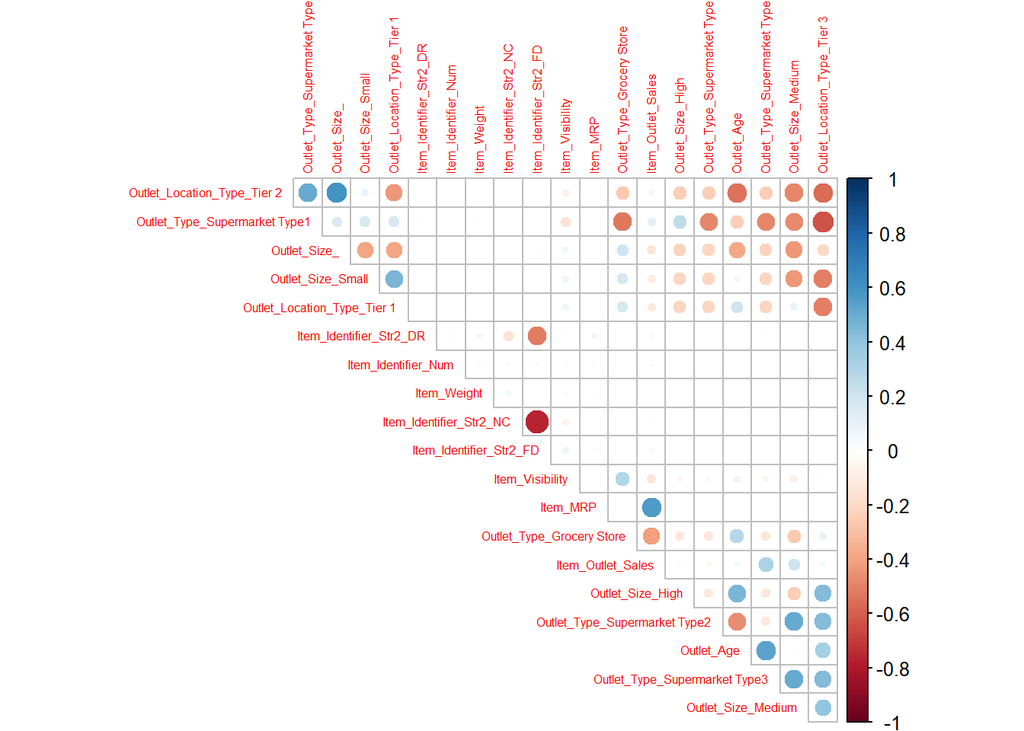

```r
library("corrplot")
library(RColorBrewer)

M<-cor(pred_train)

corrplot(M, diag = FALSE, order = "FPC",
         tl.pos = "td", tl.cex = 0.5, method = "circle", type = "upper")
```

- Simple model from kernel ([https://www.analyticsvidhya.com](https://www.analyticsvidhya.com/blog/2016/02/complete-tutorial-learn-data-science-scratch/#five)).

```r
#create a new variable in test file
test$Item_Outlet_Sales <- -999

#combine train and test data
combi <- rbind(train, test)

#impute missing value in Item_Weight
combi$Item_Weight[is.na(combi$Item_Weight)] <- median(combi$Item_Weight, na.rm = TRUE)

#impute 0 in item_visibility
combi$Item_Visibility <- ifelse(combi$Item_Visibility == 0, median(combi$Item_Visibility),                         combi$Item_Visibility)

#rename level in Outlet_Size
levels(combi$Outlet_Size)[1] <- "Other"

#rename levels of Item_Fat_Content
library(plyr)
combi$Item_Fat_Content <- revalue(combi$Item_Fat_Content,c("LF" = "Low Fat", "reg" = "Regular"))
combi$Item_Fat_Content <- revalue(combi$Item_Fat_Content, c("low fat" = "Low Fat"))

#create a new column 2013 - Year
combi$Year <- 2013 - combi$Outlet_Establishment_Year

#drop variables not required in modeling
library(dplyr)
combi <- select(combi, -c(Item_Identifier, Outlet_Identifier, Outlet_Establishment_Year))

#divide data set
new_train <- combi[1:nrow(train),]
new_test <- combi[-(1:nrow(train)),]

#linear regression
linear_model_simple <- lm(Item_Outlet_Sales ~ ., data = new_train)
summary(linear_model_simple)
```

```
##
## Call:
## lm(formula = Item_Outlet_Sales ~ ., data = new_train)
##
## Residuals:
##     Min      1Q  Median      3Q     Max
## -4336.2  -680.8   -89.8   568.3  7946.1
##
## Coefficients:
##                                  Estimate Std. Error t value Pr(>|t|)
## (Intercept)                    -977.43100  304.34139  -3.212 0.001325 **
## Item_Weight                      -0.51139    2.91490  -0.175 0.860738
## Item_Fat_ContentRegular          40.50509   28.23186   1.435 0.151401
## Item_Visibility                -255.77401  263.78199  -0.970 0.332253
## Item_TypeBreads                   5.25222   84.04714   0.062 0.950173
## Item_TypeBreakfast                6.26997  116.59546   0.054 0.957115
## Item_TypeCanned                  25.28447   62.76864   0.403 0.687091
## Item_TypeDairy                  -41.05177   62.22667  -0.660 0.509456
## Item_TypeFrozen Foods           -28.00838   58.86986  -0.476 0.634252
## Item_TypeFruits and Vegetables   29.84893   54.95872   0.543 0.587065
## Item_TypeHard Drinks             -0.07955   90.18745  -0.001 0.999296
## Item_TypeHealth and Hygiene     -10.09434   68.02370  -0.148 0.882035
## Item_TypeHousehold              -39.12266   59.92886  -0.653 0.513891
## Item_TypeMeat                    -0.35463   70.66270  -0.005 0.995996
## Item_TypeOthers                 -21.27266   98.62482  -0.216 0.829232
## Item_TypeSeafood                184.55373  148.00848   1.247 0.212464
## Item_TypeSnack Foods            -11.48660   55.25066  -0.208 0.835312
## Item_TypeSoft Drinks            -27.46544   70.16973  -0.391 0.695501
## Item_TypeStarchy Foods           21.86315  103.04028   0.212 0.831971
## Item_MRP                         15.56477    0.19769  78.733  < 2e-16 ***
## Outlet_SizeHigh                 849.13529  256.29910   3.313 0.000927 ***
## Outlet_SizeMedium               170.93952   71.08120   2.405 0.016200 *
## Outlet_SizeSmall                144.05363   45.67140   3.154 0.001615 **
## Outlet_Location_TypeTier 2     -100.36636   90.23496  -1.112 0.266050
## Outlet_Location_TypeTier 3     -326.31974  154.89294  -2.107 0.035169 *
## Outlet_TypeSupermarket Type1   1473.06659  140.73922  10.467  < 2e-16 ***
## Outlet_TypeSupermarket Type2   1076.77568  136.08116   7.913 2.83e-15 ***
## Outlet_TypeSupermarket Type3   3639.29114  178.13923  20.429  < 2e-16 ***
## Year                            -34.82155   10.49271  -3.319 0.000908 ***
## ---
## Signif. codes:  0 '***' 0.001 '**' 0.01 '*' 0.05 '.' 0.1 ' ' 1
##
## Residual standard error: 1129 on 8494 degrees of freedom
## Multiple R-squared:  0.5637, Adjusted R-squared:  0.5623
## F-statistic:   392 on 28 and 8494 DF,  p-value: < 2.2e-16
```

- Lets Visiulize simple model

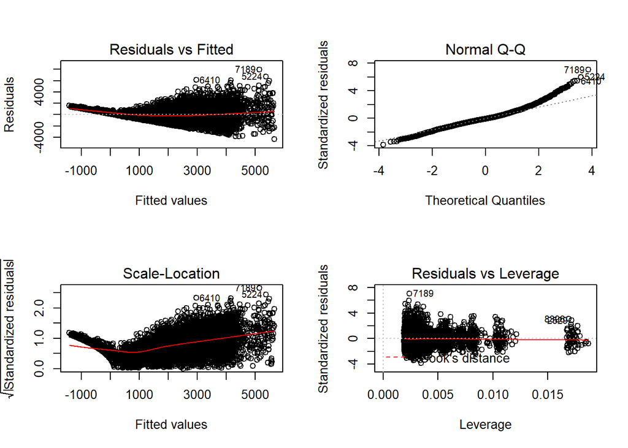

```r
par(mfrow = c(2,2))
plot(linear_model_simple)
```

- Simple model with log function from kernel ([https://www.analyticsvidhya.com](https://www.analyticsvidhya.com/blog/2016/02/complete-tutorial-learn-data-science-scratch/#five)).

```r
linear_model_log <- lm(log(Item_Outlet_Sales) ~ ., data = new_train)
summary(linear_model)
```

[output not shown]

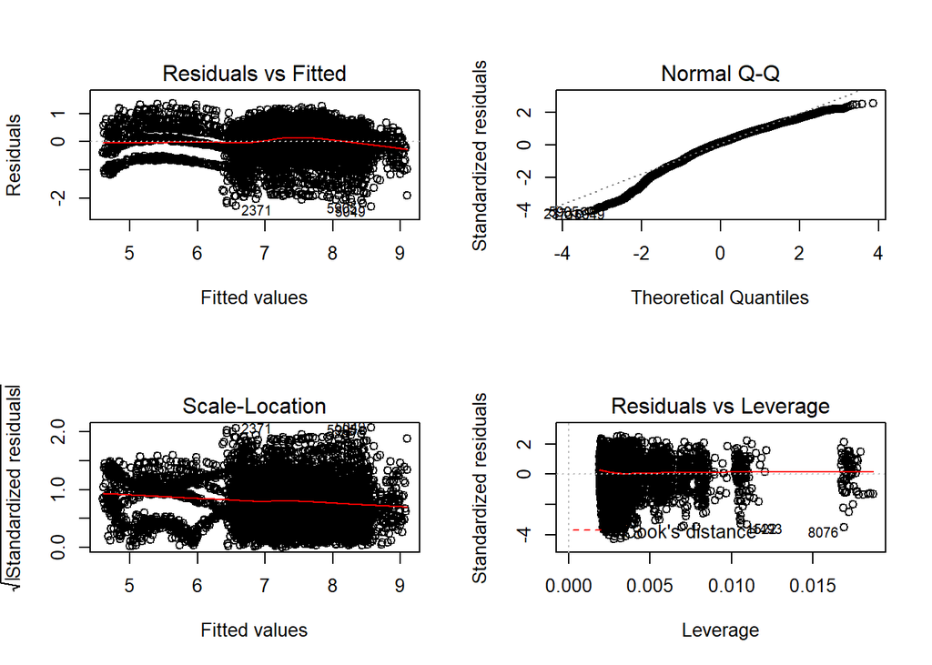

```r
par(mfrow = c(2,2))
plot(linear_model_log)
```

- Decision Tree model from kernel ([https://www.analyticsvidhya.com](https://www.analyticsvidhya.com/blog/2016/02/complete-tutorial-learn-data-science-scratch/#five)).

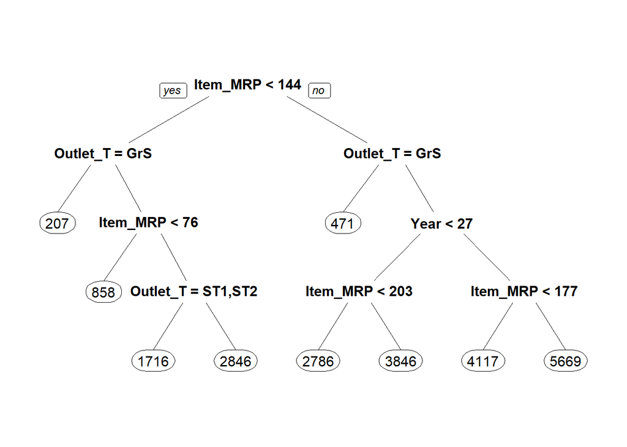

```r
library(rpart)
library(e1071)
library(rpart.plot)
library(caret)

#setting the tree control parameters
fitControl <- trainControl(method = "cv", number = 5)
cartGrid <- expand.grid(.cp=(1:50)*0.01)

#decision tree
tree_model <- train(Item_Outlet_Sales ~ ., data = new_train, method = "rpart", trControl = fitControl, tuneGrid = cartGrid)
#print(tree_model)

main_tree <- rpart(Item_Outlet_Sales ~ ., data = new_train, control = rpart.control(cp=0.01))
prp(main_tree)
```

- Compare Kernels Model RMSE, Best model created with Decision Tree Algorithm.

```r
library(Metrics)

rmse(new_train$Item_Outlet_Sales, linear_model$fitted.values)
```

```
## [1] 1126.362
```

```r
rmse(new_train$Item_Outlet_Sales, linear_model_simple$fitted.values)
```

```
## [1] 1127.081
```

```r
rmse(new_train$Item_Outlet_Sales, exp(linear_model_log$fitted.values))
```

```
## [1] 1140.004
```

```r
pre_score <- predict(main_tree, type = "vector")
rmse(new_train$Item_Outlet_Sales, pre_score)
```

```
## [1] 1102.774
```

### 4. Creating own models based on datacamp courses

statistical-modeling-in-r-part-1

- Create one lm and one rpart model, find case by case differences between predictions and real sales value and calculate mean.

```r
lm_model_1 <- lm(Item_Outlet_Sales ~ ., data = new_train)
rpart_model_1 <- rpart(Item_Outlet_Sales ~ ., data = new_train)

lm_model_1_output <- predict(lm_model_1, newdata = new_train)
rpart_model_1_output <- predict(rpart_model_1, newdata = new_train)

# Find the case by case differences

lm_model_1_diff <- with(new_train, Item_Outlet_Sales - lm_model_1_output)
rpart_model_1_diff <- with(new_train, Item_Outlet_Sales - rpart_model_1_output)

# Calculate the mean square errors
mean(lm_model_1_diff)
```

```
## [1] 6.105024e-11
```

```r
mean(rpart_model_1_diff)
```

```
## [1] 1.151509e-12
```

- Generate a random TRUE or FALSE for each case in new_train. Create one lm and one rpart model with True datasets, Make predictions with FALSE datasets and find case by case differences between predictions and real sales value and calculate mean for two models.

```r
(formula <- as.formula(Item_Outlet_Sales ~ Item_Weight + Item_Fat_Content + Item_Visibility + Item_Type + Item_MRP + Outlet_Size +
  Outlet_Location_Type + Outlet_Type + Year))
```

```
## Item_Outlet_Sales ~ Item_Weight + Item_Fat_Content + Item_Visibility +
##     Item_Type + Item_MRP + Outlet_Size + Outlet_Location_Type +
##     Outlet_Type + Year
```

```r
new_train$training_cases <- rnorm(nrow(new_train)) > 0

# summary(new_train$training_cases)

lm_model_1 <- lm(formula, data = subset(new_train, training_cases))
rpart_model_1 <- rpart(formula, data = subset(new_train, training_cases))

lm_preds <- predict(lm_model_1, newdata = subset(new_train, !training_cases))
rpart_preds <- predict(rpart_model_1, newdata = subset(new_train, !training_cases))

# Find the mean of case by case differences

with(subset(new_train, !training_cases), mean((Item_Outlet_Sales - lm_preds) ^ 2))
```

```
## [1] 1306696
```

```r
with(subset(new_train, !training_cases), mean((Item_Outlet_Sales - rpart_preds) ^ 2))
```

```
## [1] 1271804
```

### References

#### Dataset

- [Big Mart Sales Practise Problem](https://datahack.analyticsvidhya.com/contest/practice-problem-big-mart-sales-iii/)

#### Analysis & Graphs

- https://cran.r-project.org/web/packages/dplyr/vignettes/dplyr.html
- https://www.rstudio.com/resources/cheatsheets/
- https://mef-bda503.github.io/files/02_Tidyverse.html#1
- [Udacity Data Analysis with R - Lesson 3 and 5](https://classroom.udacity.com/courses/ud651)
- [DataCamp - Cleaning Data with R](https://www.datacamp.com/courses/cleaning-data-in-r)
- [R Project-An Introduction to corrplot Package](https://cran.r-project.org/web/packages/corrplot/vignettes/corrplot-intro.html)
- https://plot.ly/ggplot2/
- http://tutorials.iq.harvard.edu/R/Rgraphics/Rgraphics.html
- http://ggplot2.tidyverse.org/

#### Modeling

- statistical-modeling-in-r-part-1
- https://www.analyticsvidhya.com/blog/2016/02/complete-tutorial-learn-data-science-scratch/#five